# Detectives del Mercado Inmobiliario

Taller — Notaría 2 de Cali, 1938–1943

Nombre: _________________________ | Grupo: ___

Introducción a la Complejidad 2026-I — Universidad del Valle

## La misión

En 1984, el sociólogo John Padgett estudiaba la Florencia del siglo XV con una pregunta incómoda: ¿cómo logró una familia de banqueros de segunda categoría, los Medici, controlar la república más sofisticada de Europa? Su respuesta fue una red. Los Medici no eran los más ricos ni los más poderosos en ninguna dimensión por separado. Pero ocupaban una posición única: eran el nodo que conectaba grupos que de otra forma no se hablaban.

Este taller propone la misma operación, pero en Cali, entre 1938 y 1943. Los registros de la Notaría 2 nos dejaron un expediente de transacciones inmobiliarias: compraventas de casas y lotes, hipotecas, cancelaciones de deuda, constituciones de sociedades. Detrás de cada registro hay personas reales que están construyendo —literalmente— la ciudad que habitamos hoy.

Tu misión como detective histórico es analizar esa red para responder:

> **¿Quién controlaba el mercado inmobiliario de Cali entre 1938 y 1943? ¿Cómo se relacionaban entre sí? ¿Qué dice eso sobre el proceso de urbanización de la ciudad?**

Trabaja los siete actos en orden. Al final de cada uno hay un **Ejercicio** con preguntas que debes responder en texto, basándote en los resultados del código.

# 1 Paquetes

```r
library(igraph)
library(dplyr)
library(stringr)
```

# 2 Acto 1: Conocer el expediente

Antes de analizar cualquier fuente histórica hay que leerla con cuidado. ¿Qué contiene? ¿Qué período cubre? ¿Qué operaciones registra?

## 2.1 Cargar y explorar

```r
datos_raw <- read.csv("Base de datos notaria 2.csv",
                      fileEncoding = "UTF-8",
                      stringsAsFactors = FALSE)

cat("Total de registros:", nrow(datos_raw), "\n")
```

```
## Total de registros: 259
```

```r
cat("Columnas:", paste(names(datos_raw), collapse = ", "), "\n")
```

```
## Columnas: vendedor, comprador, Valor, Negocio, fecha
```

```r
head(datos_raw, 15)
```

|  | vendedor | comprador | Valor | Negocio | fecha |
| --- | --- | --- | --- | --- | --- |
| 1 | ana borrero | ignacio sinisterra | 700,00 | hipoteca sobre lote de terrenos en la charmea 1% | 1938 |
| 2 | ana borrero | mercedes villegas | 450,00 | vende 300 m2 de terreno en la chamea | 1938 |
| 3 | ana borrero | emilia mejia de borrero fragoni | 300,00 | vende 150 m2 de terreno en la chamea | 1938 |
| 4 | N/A | ana maria martinez velez | 700,00 | vende 722 m2 de terreno en la chamea | 1938 |
| 5 | aida micaela velasco garcia | gero velasco garcia | 1.600,00 | vende derecho sobre casa en Cali cra. 3a calles 14-15 | 1938 |
| 6 | susana vinasco de quintana | rashid eff muhnmaa | 1.500,00 | vende casa en cali calle 5 carrera 4a area 5.33 x 34-66 | 1938 |
| 7 | emilia mejia de borrero fragoni | dominga guiterrez de jeager | 461,00 | cancelacion de saldo de compraventa | 1938 |
| 8 | banco agrario hipotecario | joaquina hurtado de piedrahita | 4.000,00 | cancelacion de saldo de compraventa | 1938 |
| 9 | marco a tejada | georgina jaramillo de sarria | 1.000,00 | vende casa en cali calle 23 carrera 1a y 5a area 12-17x57-10 | 1938 |
| 10 | francisco de paula barona | agustin velasco b | 500,00 | vende mejoras ubicadas en candelaria | 1938 |

[output cut: 5 more lines]

```r
cat("Registros por año:\n")
```

```
## Registros por año:
```

```r
table(datos_raw$fecha)
```

```
##
## 1938 1939 1940 1941 1943
##   41   72   62   18   66
```

## 2.2 Tipos de transacción

No todas las operaciones son iguales. Clasificamos el contenido de la columna `Negocio` para ver qué tipo de actos jurídicos predominan.

```r
datos_raw <- datos_raw %>%
  mutate(tipo = case_when(
    str_detect(str_to_lower(coalesce(Negocio, "")),
               "vende|venta|reventa|revende") ~ "Compraventa",
    str_detect(str_to_lower(coalesce(Negocio, "")),
               "hipoteca|aseguro de deuda|garantia") ~ "Hipoteca",
    str_detect(str_to_lower(coalesce(Negocio, "")),
               "cancelac") ~ "Cancelación",
    str_detect(str_to_lower(coalesce(Negocio, "")),
               "constituye|sociedad|modific") ~ "Sociedad / Constitución",
    str_detect(str_to_lower(coalesce(Negocio, "")),
               "donac") ~ "Donación",
    TRUE ~ "Otro / Sin clasificar"
  ))

cat("Distribución por tipo de transacción:\n")
```

```
## Distribución por tipo de transacción:
```

```r
sort(table(datos_raw$tipo), decreasing = TRUE)
```

```
##
##             Compraventa   Otro / Sin clasificar                Hipoteca
##                     144                      59                      26
##             Cancelación Sociedad / Constitución                Donación
##                      20                       6                       4
```

## 2.3 Rango de valores

```r
vals_temp <- datos_raw$Valor %>%
  str_replace_all("\\$", "") %>%
  str_replace_all("\\.", "") %>%
  str_replace_all(",", ".") %>%
  str_trim() %>%
  as.numeric()

cat(sprintf("Valor mínimo  : $%s pesos\n", format(min(vals_temp, na.rm=TRUE), big.mark=".")))
```

```
## Valor mínimo  : $80 pesos
```

```r
cat(sprintf("Valor mediana : $%s pesos\n", format(median(vals_temp, na.rm=TRUE), big.mark=".")))
```

```
## Valor mediana : $1.700 pesos
```

```r
cat(sprintf("Valor máximo  : $%s pesos\n", format(max(vals_temp, na.rm=TRUE), big.mark=".")))
```

```
## Valor máximo  : $731.041 pesos
```

```r
cat(sprintf("Sin valor     : %d registros\n", sum(is.na(vals_temp))))
```

```
## Sin valor     : 3 registros
```

**Ejercicio 1 — El expediente**

1. ¿Cuántos registros tiene el expediente? ¿Qué años cubre? ¿Hay algún año que destaque por volumen?
2. ¿Cuál es el tipo de transacción más frecuente? ¿Qué dice eso sobre qué tipo de actividad captura esta notaría?
3. La transacción más grande supera en mucho a la mediana. ¿Qué hipótesis tienes sobre quiénes hacen las transacciones de mayor valor?

*Escribe tus respuestas aquí (reemplaza el guion):*

> 1. —
> 2. —
> 3. —

# 3 Acto 2: Depurar las pistas

Los archivos históricos son imperfectos. Una misma persona puede aparecer escrita de tres formas distintas: `"ana borrero"`, `"Ana Borrero"` y `"ana borrero "` (con espacio al final) serían tres nodos separados si no limpiamos. Antes de construir la red, estandarizamos.

## 3.1 Estandarizar nombres

```r
# Cargamos stringi para limpieza avanzada de texto
if(!require(stringi)) install.packages("stringi")
library(stringi)

limpiar_nombre <- function(x) {
  x %>%
    stri_trans_general("Latin-ASCII") %>% # Elimina tildes y caracteres especiales
    str_trim() %>%
    str_squish() %>%
    str_to_lower() %>%                    # Todo a minúscula para comparar mejor
    str_to_title() %>%                    # Luego a Formato Nombre Propio
    str_replace_all("\\bDe\\b",  "de")  %>%
    str_replace_all("\\bDel\\b", "del") %>%
    str_replace_all("\\bY\\b",   "y")   %>%
    na_if("N/A") %>%
    na_if("NA")  %>%
    na_if("")
}

datos_raw$vendedor  <- limpiar_nombre(datos_raw$vendedor)
datos_raw$comprador <- limpiar_nombre(datos_raw$comprador)

cat("Nombres estandarizados: tildes eliminadas y espacios corregidos.\n")
```

```
## Nombres estandarizados: tildes eliminadas y espacios corregidos.
```

## 3.2 Limpiar valores monetarios

```r
limpiar_valor <- function(x) {
  x %>%
    str_replace_all("\\$", "") %>%
    str_replace_all("\\.", "") %>%
    str_replace_all(",", ".") %>%
    str_trim() %>%
    as.numeric()
}

datos_raw$Valor <- limpiar_valor(datos_raw$Valor)
datos_raw$fecha <- as.integer(datos_raw$fecha)
```

## 3.3 Filtrar registros incompletos

Para construir la red necesitamos que **ambos extremos** del vínculo estén presentes: sin vendedor o sin comprador, no hay arista.

```r
datos <- datos_raw %>%
  filter(!is.na(vendedor), !is.na(comprador)) %>%
  filter(vendedor != comprador)   # eliminamos auto-transacciones

cat("Registros originales  :", nrow(datos_raw), "\n")
```

```
## Registros originales  : 259
```

```r
cat("Registros usables     :", nrow(datos), "\n")
```

```
## Registros usables     : 257
```

```r
cat("Registros eliminados  :", nrow(datos_raw) - nrow(datos), "\n")
```

```
## Registros eliminados  : 2
```

```r
head(datos %>% select(vendedor, comprador, Valor, tipo, fecha), 12)
```

|  | vendedor | comprador | Valor | tipo | fecha |
| --- | --- | --- | --- | --- | --- |
| 1 | Ana Borrero | Ignacio Sinisterra | 700 | Hipoteca | 1938 |
| 2 | Ana Borrero | Mercedes Villegas | 450 | Compraventa | 1938 |
| 3 | Ana Borrero | Emilia Mejia de Borrero Fragoni | 300 | Compraventa | 1938 |
| 4 | Aida Micaela Velasco Garcia | Gero Velasco Garcia | 1600 | Compraventa | 1938 |
| 5 | Susana Vinasco de Quintana | Rashid Eff Muhnmaa | 1500 | Compraventa | 1938 |
| 6 | Emilia Mejia de Borrero Fragoni | Dominga Guiterrez de Jeager | 461 | Compraventa | 1938 |
| 7 | Banco Agrario Hipotecario | Joaquina Hurtado de Piedrahita | 4000 | Compraventa | 1938 |
| 8 | Marco A Tejada | Georgina Jaramillo de Sarria | 1000 | Compraventa | 1938 |
| 9 | Francisco de Paula Barona | Agustin Velasco B | 500 | Compraventa | 1938 |
| 10 | Rafael Sinisterra | Julia Castro de Rojas | 3800 | Compraventa | 1938 |

[output cut: 2 more lines]

**Ejercicio 2 — Las imperfecciones del archivo**

1. ¿Cuántos registros se eliminaron por estar incompletos? ¿Por qué ese filtro es necesario para construir una red?
2. El expediente cubre 1938, 1939, 1940, 1941 y 1943 — **falta 1942**. Formula al menos dos hipótesis sobre esa ausencia. ¿Qué fuentes consultarías para confirmar o descartar cada una?
3. Los errores de codificación (mayúsculas, espacios, formatos) son comunes en fuentes digitalizadas. ¿Qué consecuencia tendría analizar la red *sin* limpiar los datos? ¿Inflaría o reduciría el número de nodos?

*Escribe tus respuestas aquí:*

> 1. —
> 2. —
> 3. —

# 4 Acto 3: Los sospechosos

Antes de construir la red completa, identifiquemos a los actores más relevantes. ¿Quiénes participan más en el mercado?

## 4.1 Los más activos

```r
vendedores  <- datos %>% count(vendedor,  name = "veces_vendedor")  %>% rename(actor = vendedor)
compradores <- datos %>% count(comprador, name = "veces_comprador") %>% rename(actor = comprador)

actividad <- full_join(vendedores, compradores, by = "actor") %>%
  replace(is.na(.), 0) %>%
  mutate(total = veces_vendedor + veces_comprador) %>%
  arrange(desc(total))

cat("Top 20 actores por total de apariciones:\n")
```

```
## Top 20 actores por total de apariciones:
```

```r
head(actividad, 20)
```

|  | actor | veces_vendedor | veces_comprador | total |
| --- | --- | --- | --- | --- |
| 1 | Sebastian Caicedo | 5 | 8 | 13 |
| 2 | Ana Borrero | 7 | 1 | 8 |
| 3 | Banco Central Hipotecario | 1 | 7 | 8 |
| 4 | Susana Caicedo | 6 | 0 | 6 |
| 5 | Sociedad Urbanizadora Colombiana | 5 | 0 | 5 |
| 6 | Banco de Colombia | 2 | 2 | 4 |
| 7 | Emilia Gasca V de Barney | 4 | 0 | 4 |
| 8 | Jose Ricci | 2 | 2 | 4 |
| 9 | Rosa Lowid de Arboleda | 4 | 0 | 4 |
| 10 | Banco Agrario Hipotecario | 2 | 1 | 3 |

[output cut: 10 more lines]

## 4.2 ¿Quiénes son: personas o instituciones?

No todos los actores son individuos. Clasificamos el top de actores detectando palabras clave como “Banco”, “Sociedad”, “Compania” o “Cia”.

```r
identificar_tipo <- function(nombre) {
  n <- str_to_lower(nombre)
  case_when(
    str_detect(n, "banco|caja|credito|hipotecario") ~ "Institución Financiera",
    str_detect(n, "sociedad|cia|compania|hijos|hermanos|ltda|sucesores") ~ "Empresa / Familia",
    TRUE ~ "Persona Natural"
  )
}

actividad <- actividad %>%
  mutate(tipo_actor = identificar_tipo(actor))

cat("Clasificación de los 15 más activos:\n")
```

```
## Clasificación de los 15 más activos:
```

```r
head(actividad %>% select(actor, total, tipo_actor), 15)
```

|  | actor | total | tipo_actor |
| --- | --- | --- | --- |
| 1 | Sebastian Caicedo | 13 | Persona Natural |
| 2 | Ana Borrero | 8 | Persona Natural |
| 3 | Banco Central Hipotecario | 8 | Institución Financiera |
| 4 | Susana Caicedo | 6 | Persona Natural |
| 5 | Sociedad Urbanizadora Colombiana | 5 | Empresa / Familia |
| 6 | Banco de Colombia | 4 | Institución Financiera |
| 7 | Emilia Gasca V de Barney | 4 | Persona Natural |
| 8 | Jose Ricci | 4 | Persona Natural |
| 9 | Rosa Lowid de Arboleda | 4 | Persona Natural |
| 10 | Banco Agrario Hipotecario | 3 | Institución Financiera |

[output cut: 5 more lines]

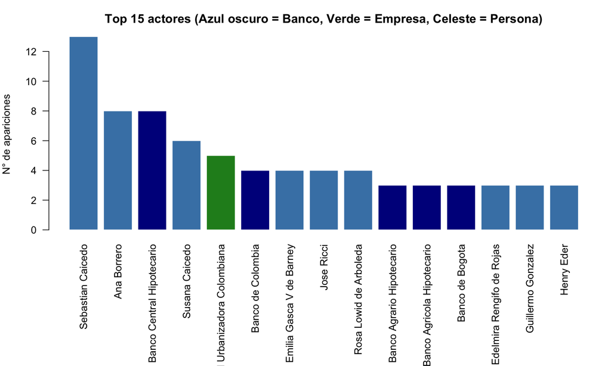

```r
top15 <- head(actividad, 15)

# Definimos colores por tipo
colores <- case_when(
  top15$tipo_actor == "Institución Financiera" ~ "darkblue",
  top15$tipo_actor == "Empresa / Familia" ~ "forestgreen",
  TRUE ~ "steelblue"
)

par(mar = c(11, 4, 3, 1))
barplot(
  top15$total,
  names.arg = top15$actor,
  las = 2,
  col = colores,
  border = "white",
  main = "Top 15 actores (Azul oscuro = Banco, Verde = Empresa, Celeste = Persona)",
  ylab = "N° de apariciones"
)
```

## 4.3 ¿Compran o venden más?

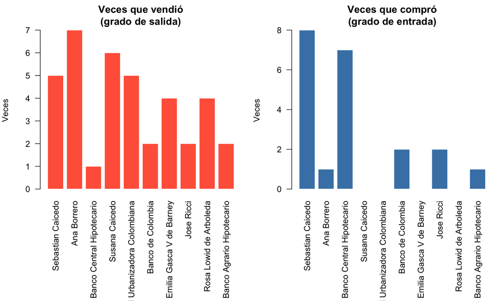

```r
top10 <- head(actividad, 10)

par(mfrow = c(1, 2), mar = c(11, 4, 3, 1))

barplot(top10$veces_vendedor,
        names.arg = top10$actor, las = 2,
        col = "tomato", border = "white",
        main = "Veces que vendió\n(grado de salida)",
        ylab = "Veces")

barplot(top10$veces_comprador,
        names.arg = top10$actor, las = 2,
        col = "steelblue", border = "white",
        main = "Veces que compró\n(grado de entrada)",
        ylab = "Veces")
```

```r
par(mfrow = c(1, 1))
```

**Pista del historiador**

Jorge Garcés Borrero (1899–1944) fue una figura central en la élite caleña de este período. Jaime Londoño (2019) le dedicó una biografía titulada *Optimismo, tesón y labor*. Búscalo en los datos: ¿aparece como vendedor, como comprador, o como ambos? La Sociedad Urbanizadora Colombiana también aparece: es una empresa que parcelaba y vendía terrenos en los nuevos barrios de expansión (Versalles, Granada, Centenario). Su presencia dice mucho sobre la lógica del negocio inmobiliario de la época.

**Ejercicio 3 — Los sospechosos**

1. ¿Quiénes son los 5 actores más activos? ¿Son personas naturales, familias, empresas o instituciones financieras? ¿Qué patrón observas?
2. Sebastián Caicedo aparece repetidamente. Observa si compra o vende más. ¿Qué rol histórico podría estar cumpliendo? (Piensa en: especulador de suelo, intermediario, constructor de barrio popular)
3. Los bancos (Banco Agrario, Banco Central Hipotecario) aparecen en ambos roles. ¿Cuándo actúan como vendedores y cuándo como compradores? ¿Qué función cumplen en el mercado inmobiliario?

*Escribe tus respuestas aquí:*

> 1. —
> 2. —
> 3. —

# 5 Acto 4: El mapa de relaciones

Construimos la red. Cada actor es un nodo. Cada transacción es un vínculo **dirigido** (vendedor → comprador) con un **peso** igual al valor en pesos.

## 5.1 Construir el grafo

```r
aristas <- datos %>%
  select(from = vendedor, to = comprador, peso = Valor, tipo, fecha) %>%
  filter(!is.na(peso))

# Cuando hay múltiples transacciones entre los mismos actores, las agregamos
aristas_ag <- aristas %>%
  group_by(from, to) %>%
  summarise(
    peso      = sum(peso, na.rm = TRUE),
    n_transac = n(),
    .groups   = "drop"
  )

g <- graph_from_data_frame(aristas_ag, directed = TRUE)

cat("=== Red Inmobiliaria de Cali (1938–1943) ===\n")
```

```
## === Red Inmobiliaria de Cali (1938–1943) ===
```

```r
cat("Nodos (actores)    :", vcount(g), "\n")
```

```
## Nodos (actores)    : 421
```

```r
cat("Aristas (vínculos) :", ecount(g), "\n")
```

```
## Aristas (vínculos) : 251
```

## 5.2 Estructura general

```r
comp <- components(g, mode = "weak")

cat("¿Es débilmente conexa?           :", is_connected(g, mode = "weak"), "\n")
```

```
## ¿Es débilmente conexa?           : FALSE
```

```r
cat("Número de componentes            :", comp$no, "\n")
```

```
## Número de componentes            : 171
```

```r
cat("Tamaño del componente gigante    :", max(comp$csize), "nodos\n")
```

```
## Tamaño del componente gigante    : 15 nodos
```

```r
cat("Actores fuera del componente     :", vcount(g) - max(comp$csize), "nodos\n")
```

```
## Actores fuera del componente     : 406 nodos
```

```r
cat("Densidad de la red               :", round(edge_density(g), 4), "\n")
```

```
## Densidad de la red               : 0.0014
```

```r
cat("Reciprocidad (A→B y B→A)        :", round(reciprocity(g), 3), "\n")
```

```
## Reciprocidad (A→B y B→A)        : 0.008
```

## 5.3 Visualización: Los puentes del mercado

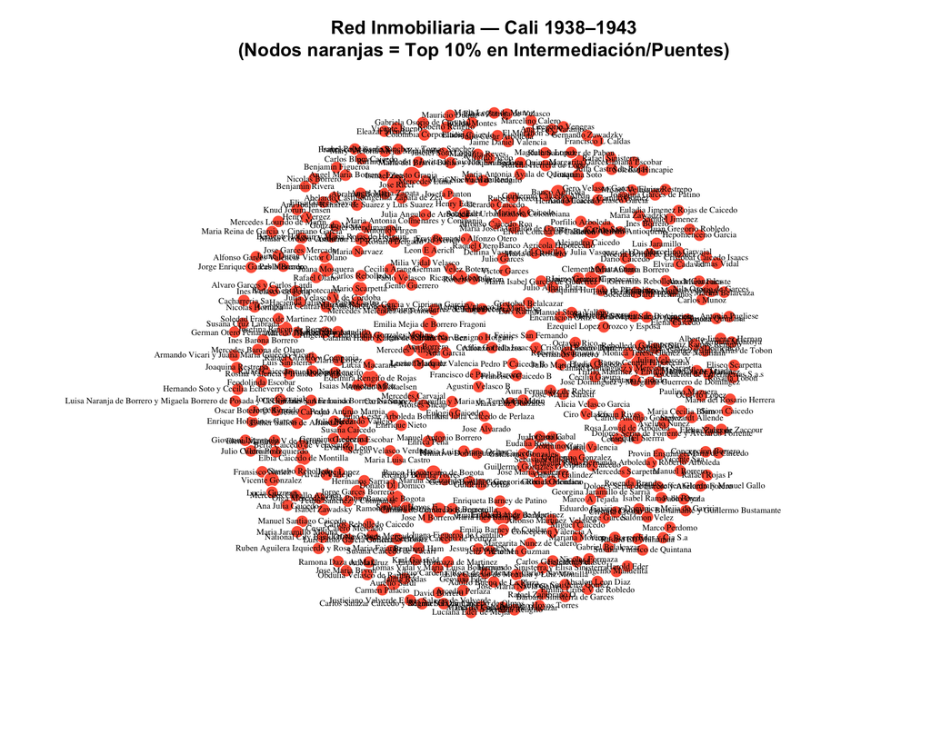

```r
set.seed(42)

grado_total <- degree(g, mode = "all")
betw_val    <- betweenness(g, normalized = TRUE)
umbral_betw <- quantile(betw_val, 0.90)

# Color: Naranja si es puente importante, Celeste si no
colores_nodos <- ifelse(betw_val >= umbral_betw, "tomato", "skyblue")
pesos_norm    <- log1p(E(g)$peso) / max(log1p(E(g)$peso)) * 4 + 0.5

plot(g,
     layout          = layout_with_fr(g),
     vertex.size     = sqrt(grado_total) * 3 + 2,
     vertex.color    = colores_nodos,
     vertex.frame.color = "white",
     vertex.label    = ifelse(grado_total >= quantile(grado_total, 0.85) |
                              betw_val >= umbral_betw,
                              V(g)$name, NA),
     vertex.label.cex   = 0.55,
     vertex.label.color = "black",
     edge.width      = pesos_norm,
     edge.color      = adjustcolor("gray40", alpha.f = 0.5),
     edge.arrow.size = 0.2,
     main = "Red Inmobiliaria — Cali 1938–1943\n(Nodos naranjas = Top 10% en Intermediación/Puentes)"
)
```

**Ejercicio 4 — El mapa**

1. La red tiene varios **componentes desconectados**. ¿Qué significa eso históricamente? ¿El mercado inmobiliario de Cali era unificado o estaba fragmentado en circuitos separados?
2. La **densidad** es muy baja (cercana a 0). ¿Qué implica: que todos comerciaban con todos, o que las transacciones seguían patrones muy selectivos? ¿Cuál es más plausible para una ciudad de ese tamaño en esa época?
3. La **reciprocidad** indica qué proporción de vínculos va en ambas direcciones (A vendió a B *y* B vendió a A). ¿Es alta o baja? ¿Qué dice sobre el mercado: los actores alternan roles de comprador y vendedor, o tienden a especializarse?

*Escribe tus respuestas aquí:*

> 1. —
> 2. —
> 3. —

# 6 Acto 5: ¿Quién manda?

Las medidas de centralidad revelan distintas formas de poder en la red. No es lo mismo tener muchas transacciones que ser el puente entre actores que de otra forma no se encontrarían.

## 6.1 Grado de entrada y salida

```r
grado_out <- degree(g, mode = "out")
grado_in  <- degree(g, mode = "in")

tabla_grado <- data.frame(
  Actor    = V(g)$name,
  Vendió_a = grado_out,
  Compró_a = grado_in,
  Total    = grado_out + grado_in
) %>% arrange(desc(Total))

rownames(tabla_grado) <- NULL

cat("Top 20 actores por grado total:\n")
```

```
## Top 20 actores por grado total:
```

```r
head(tabla_grado, 20)
```

|  | Actor | Vendió_a | Compró_a | Total |
| --- | --- | --- | --- | --- |
| 1 | Sebastian Caicedo | 5 | 7 | 12 |
| 2 | Ana Borrero | 7 | 1 | 8 |
| 3 | Banco Central Hipotecario | 1 | 7 | 8 |
| 4 | Susana Caicedo | 6 | 0 | 6 |
| 5 | Sociedad Urbanizadora Colombiana | 5 | 0 | 5 |
| 6 | Emilia Gasca V de Barney | 4 | 0 | 4 |
| 7 | Jose Ricci | 2 | 2 | 4 |
| 8 | Rosa Lowid de Arboleda | 4 | 0 | 4 |
| 9 | Banco Agrario Hipotecario | 2 | 1 | 3 |
| 10 | Banco Agricola Hipotecario | 3 | 0 | 3 |

[output cut: 10 more lines]

## 6.2 Intermediación (*betweenness*)

¿Quién actúa como **puente** entre partes del mercado que de otra forma no se conectarían? Un actor con alta intermediación puede controlar flujos de información, crédito o tierra sin ser necesariamente el más rico.

```r
betw <- betweenness(g, directed = TRUE, normalized = TRUE)

tabla_betw <- data.frame(
  Actor          = V(g)$name,
  Intermediación = round(betw, 4)
) %>% arrange(desc(Intermediación))

rownames(tabla_betw) <- NULL

cat("Top 15 actores por intermediación:\n")
```

```
## Top 15 actores por intermediación:
```

```r
head(tabla_betw, 15)
```

|  | Actor | Intermediación |
| --- | --- | --- |
| 1 | Sebastian Caicedo | 2e-04 |
| 2 | Abelardo Astudillo | 0e+00 |
| 3 | Abelardo Castillo | 0e+00 |
| 4 | Absalon Leon Diaz | 0e+00 |
| 5 | Adela Cruz | 0e+00 |
| 6 | Agustin Velazco B | 0e+00 |
| 7 | Aida Micaela Velasco Garcia | 0e+00 |
| 8 | Alejandro Caicedo | 0e+00 |
| 9 | Alfonso Garces Valencia | 0e+00 |
| 10 | Alfonso Martinez Velasco | 0e+00 |

[output cut: 5 more lines]

## 6.3 Volumen transado

El grado cuenta el *número* de socios distintos; la **fuerza** suma el *valor en pesos* de todas las transacciones. Son dimensiones distintas del poder.

```r
fuerza_out <- strength(g, mode = "out", weights = E(g)$peso)
fuerza_in  <- strength(g, mode = "in",  weights = E(g)$peso)

tabla_fuerza <- data.frame(
  Actor         = V(g)$name,
  Vendió_pesos  = round(fuerza_out),
  Compró_pesos  = round(fuerza_in),
  Total_pesos   = round(fuerza_out + fuerza_in)
) %>% arrange(desc(Total_pesos))

rownames(tabla_fuerza) <- NULL

cat("Top 15 actores por volumen total transado (pesos):\n")
```

```
## Top 15 actores por volumen total transado (pesos):
```

```r
head(tabla_fuerza, 15)
```

|  | Actor | Vendió_pesos | Compró_pesos | Total_pesos |
| --- | --- | --- | --- | --- |
| 1 | Banco Agrario Hipotecario | 134000 | 500 | 134500 |
| 2 | Jaime Gomez C | 0 | 130000 | 130000 |
| 3 | Silvio Cardena, Rosa de Cardenas y Carlos Navarro | 123000 | 0 | 123000 |
| 4 | Adolfo Bueno de La Plaza | 0 | 123000 | 123000 |
| 5 | Jorge Garces Borrero | 30000 | 80000 | 110000 |
| 6 | Gernando Zawadzky | 90000 | 0 | 90000 |
| 7 | Francisco L Caldas | 0 | 90000 | 90000 |
| 8 | Pedro Sanchez y Compania | 80000 | 0 | 80000 |
| 9 | Rafael Rojas P | 65891 | 0 | 65891 |
| 10 | Jorge Steffen Glomm y Manuel Gallo | 0 | 65891 | 65891 |

[output cut: 5 more lines]

## 6.4 Tabla comparativa de centralidades

```r
top20 <- head(tabla_grado$Actor, 20)

tabla_cent <- data.frame(
  Actor          = top20,
  Grado_total    = (grado_out + grado_in)[top20],
  Salida         = grado_out[top20],
  Entrada        = grado_in[top20],
  Intermediación = round(betw[top20], 3),
  Vol_pesos      = round((fuerza_out + fuerza_in)[top20])
) %>% arrange(desc(Grado_total))

rownames(tabla_cent) <- NULL

knitr::kable(tabla_cent,
             col.names = c("Actor", "Grado total", "Vendió a",
                           "Compró a", "Intermediación", "Vol. ($)"),
             caption   = "Centralidades — Red Inmobiliaria Cali 1938–1943",
             format.args = list(big.mark = "."))
```

Centralidades — Red Inmobiliaria Cali 1938–1943

| Actor | Grado total | Vendió a | Compró a | Intermediación | Vol. ($) |
| --- | --- | --- | --- | --- | --- |
| Sebastian Caicedo | 12 | 5 | 7 | 0 | 8.850 |
| Ana Borrero | 8 | 7 | 1 | 0 | 3.680 |
| Banco Central Hipotecario | 8 | 1 | 7 | 0 | 48.950 |
| Susana Caicedo | 6 | 6 | 0 | 0 | 1.706 |
| Sociedad Urbanizadora Colombiana | 5 | 5 | 0 | 0 | 19.893 |
| Emilia Gasca V de Barney | 4 | 4 | 0 | 0 | 44.424 |
| Jose Ricci | 4 | 2 | 2 | 0 | 34.080 |
| Rosa Lowid de Arboleda | 4 | 4 | 0 | 0 | 590 |
| Banco Agrario Hipotecario | 3 | 2 | 1 | 0 | 134.500 |
| Banco Agricola Hipotecario | 3 | 3 | 0 | 0 | 11.200 |
| Banco de Bogota | 3 | 2 | 1 | 0 | 26.000 |
| Banco de Colombia | 3 | 1 | 2 | 0 | 31.012 |
| Edelmira Rengifo de Rojas | 3 | 3 | 0 | 0 | 7.763 |
| Guillermo Gonzalez | 3 | 3 | 0 | 0 | 1.500 |
| Nila Osorio de Garces | 3 | 2 | 1 | 0 | 5.645 |
| Ernesto Granja | 3 | 0 | 3 | 0 | 8.470 |
| Asuncion Lopez de Salazar | 2 | 1 | 1 | 0 | 2.800 |
| Aurelio Sardi | 2 | 1 | 1 | 0 | 2.200 |
| Banco Agricola | 2 | 2 | 0 | 0 | 2.656 |
| Banco Hipotecario de Bogota | 2 | 2 | 0 | 0 | 5.500 |

**Pista del historiador**

Padgett & McLean (2006) muestran que los Medici no dominaban Florencia por ser los más ricos ni los que más transacciones hacían: dominaban porque ocupaban la posición de **intermediación** más alta. Eran el nodo que conectaba grupos que de otra forma no se hablaban, lo que les daba un poder de tipo estructural — independiente de su riqueza o estatus formal. ¿Hay algún actor en esta red que reproduzca esa lógica?

**Ejercicio 5 — ¿Quién manda?**

1. Identifica al actor con mayor **grado de salida** y al de mayor **grado de entrada**. ¿Qué roles históricos concretos representan? (Por ejemplo: loteador que vende a muchos compradores distintos, comprador activo que acumula propiedades, intermediario financiero)
2. El actor con mayor **intermediación** es un puente entre partes de la red. ¿Es una persona, una familia, una empresa o un banco? ¿Qué tipo de poder le otorga esa posición? ¿Cómo podría aprovecharlo históricamente?
3. Compara el ranking por **grado total** con el de **volumen transado**. ¿Hay actores que hacen pocas transacciones pero de mucho valor? ¿Y actores que hacen muchas transacciones de poco valor? ¿Qué diferencia histórica hay entre esas dos estrategias?

*Escribe tus respuestas aquí:*

> 1. —
> 2. —
> 3. —

# 7 Acto 6: Las camarillas

¿Hay grupos de actores que transaccionan principalmente entre sí? El algoritmo de Louvain detecta estas comunidades maximizando la **modularidad**: qué tan separados están los grupos entre sí.

## 7.1 Detectar comunidades

```r
set.seed(42)

# Para detección de comunidades trabajamos con la versión no dirigida
g_nodir <- as.undirected(g, mode = "collapse",
                          edge.attr.comb = list(peso = "sum", n_transac = "sum"))

comunidades <- cluster_louvain(g_nodir, weights = E(g_nodir)$peso)

cat("Número de comunidades:", length(comunidades), "\n")
```

```
## Número de comunidades: 171
```

```r
cat("Modularidad          :", round(modularity(comunidades), 3), "\n\n")
```

```
## Modularidad          : 0.968
```

```r
membresia <- membership(comunidades)

for (i in seq_along(comunidades)) {
  miembros <- V(g_nodir)$name[membresia == i]
  if (length(miembros) >= 3) {
    cat(sprintf("Comunidad %d (%d actores): %s%s\n",
                i, length(miembros),
                paste(head(miembros, 8), collapse = ", "),
                if (length(miembros) > 8) ", ..." else ""))
  }
}
```

```
## Comunidad 7 (5 actores): Alejandro Caicedo, Banco Aleman Antioqueno, Banco de Colombia, Porfilio Arboleda, Carlos Sardi
## Comunidad 11 (3 actores): Alfredo Herrera M, Josefina Rincon de Borrero, Soledad Franco de Martinez 2700
## Comunidad 14 (9 actores): Ana Borrero, Emilia Mejia de Borrero Fragoni, Ignacio Sinisterra, Ana Garcia, Ester Narvaez, Leonor Marquez, Lucia Tejada de Valencia, Mercedes Villegas, ...
## Comunidad 18 (7 actores): Angel Maria Zapata, Ismael Zea, Jose Ricci, Mercedes Luna, Rufino Caicedo y Jovita de Caicedo, Angelina Zapata de Zea, Ernesto Granja
## Comunidad 23 (3 actores): Asuncion Lopez de Salazar, Maria Narvaez, Ester Mendimanuela
## Comunidad 26 (3 actores): Aurelio Sardi, Jaime Rodas, Carmen Palacio
## Comunidad 27 (4 actores): Banco Agrario Hipotecario, Clemente Matta Otero, Jaime Gomez C, Joaquina Hurtado de Piedrahita
## Comunidad 28 (3 actores): Banco Agricola, Guillermo Caicedo Alban, Hernando Caicedo
## Comunidad 29 (4 actores): Banco Agricola Hipotecario, Delfina Vasquez del Castillo y Julia Vasquez del Duque, Elvira Concha de Calderon, Maria del Rosario
## Comunidad 30 (9 actores): Banco Central Hipotecario, Camilo Dominguez y Mercedes Sarasti, Cayetano Caidedo, Donato Domenico y Maria Velazco de Domenico, Jose Dominguez y Margarita Guerrero de Domingez, Julia Velasco V, Roberto Neumann y Monica Teresa Gomez de Neumann, Trifilo Martinez y Emilia Ho…
## Comunidad 31 (3 actores): Banco Hipotecario de Bogota, Marina Salazar de Castano, Ricardo Bonilla Torres
## Comunidad 32 (4 actores): Banco de Bogota, Santiago Hoyos F, Donato Di Domico, Ramon Jaramillo
## Comunidad 37 (3 actores): Berta Caicedo de Velasquez, Elbia Caicedo de Montilla, Gustabo Rebolledo
## Comunidad 39 (3 actores): Camara de Comercio Barranquilla, Jose M Borrero, Juan de Dios Borrero
## Comunidad 40 (4 actores): Carlos Munoz, Nila Osorio de Garces, Ana Maria Faraste, Marina Belarcaza
## Comunidad 43 (3 actores): Cecilia Arango, Pablo Velasco, Genlo Guerrero
## Comunidad 47 (3 actores): Cristobal Belalcazar, Luis Ramos, Francisca Monsalve
## Comunidad 54 (4 actores): Edelmira Rengifo de Rojas, Arnoldo Michaelsen, Isaias Montezuma Paz, Lucia Macarane
## Comunidad 64 (5 actores): Emilia Gasca V de Barney, Emilia Barney de Cuellar, Emilia Barney de Martinez, Enriqueta Barney de Patino, Maria Ines Barney
## Comunidad 70 (15 actores): Euladia Rojas, Gabriel Galindez, Guillermo Gonzales, Guillermo Gonzalez, Jorgino Cabal, Jose Maria Guiterrez, Juan Castillo, Sebastian Caicedo, ...
## Comunidad 75 (3 actores): Fernando Borrero, Julio Mario Lora, Octavio Rico
## Comunidad 80 (3 actores): Fransisco Nunez, Vicente Gonzalez, Lucia Guzman
## Comunidad 88 (3 actores): Gonzalo San Fernando, Jesus Carvajal, Esther Salfon de Alfandary
## Comunidad 91 (3 actores): Henry Eder, Amy Eder, Josefa Panton
## Comunidad 106 (3 actores): Jorge Garces Borrero, Pedro Sanchez y Compania, Hermanos Sarria T
## Comunidad 111 (3 actores): Juana Mosquera, Victor Olano, Rafael Olano
## Comunidad 116 (3 actores): Leon E Aerich, David Aerich, Milia Vidal Velasco
## Comunidad 125 (3 actores): Margarita Garces, Ruth Santander de Pabon, Joaquina Soto
## Comunidad 135 (3 actores): Mario Scarpetta, Carlos Rebolledo, Pablo Castro
## Comunidad 152 (3 actores): Ricardo Arboleda, German Velez Botero, Roberto Muneton
## Comunidad 154 (5 actores): Rosa Lowid de Arboleda, Carlos Antonio Gonzalez, Central B, Efrain Rivas, Esequiel Sierrra
## Comunidad 162 (6 actores): Sociedad Urbanizadora Colombiana, Alfonso Caicedo Roa, Gerardo Caicedo, Maria Josefa Giraldo de Garces, Mario de Caicedo, Ruben Orozco
## Comunidad 165 (7 actores): Susana Caicedo, Evaristo Leon, Geronimo Ledezma, Gregorio Escobar, Julio Perez, Medardo Vallejo, Pedro Antinio Marpia
```

## 7.2 Visualización

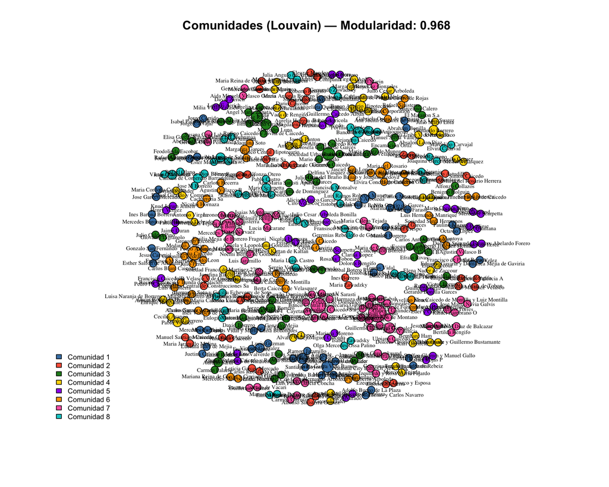

```r
set.seed(42)

paleta     <- c("steelblue","tomato","forestgreen","gold",
                "purple","orange","hotpink","cyan3")
colores_com <- paleta[membresia %% length(paleta) + 1]
grado_nd    <- degree(g_nodir)

plot(g_nodir,
     layout          = layout_with_fr(g_nodir),
     vertex.size     = sqrt(grado_nd) * 2.5 + 2,
     vertex.color    = colores_com,
     vertex.label    = ifelse(grado_nd >= quantile(grado_nd, 0.85),
                              V(g_nodir)$name, NA),
     vertex.label.cex   = 0.55,
     vertex.label.color = "black",
     edge.width      = 0.5,
     edge.color      = adjustcolor("gray60", alpha.f = 0.4),
     main            = paste0("Comunidades (Louvain) — Modularidad: ",
                              round(modularity(comunidades), 3))
)

legend("bottomleft",
       legend = paste("Comunidad", 1:min(length(comunidades), 8)),
       fill   = paleta[1:min(length(comunidades), 8)],
       cex    = 0.7, bty = "n")
```

**Ejercicio 6 — Las camarillas**

1. ¿Cuántas comunidades detecta el algoritmo? La modularidad va de 0 a 1: valores cercanos a 0.3 o más indican estructura de comunidades clara. ¿La red tiene comunidades bien definidas o es relativamente homogénea?
2. Observa los apellidos dentro de cada comunidad. ¿Reconoces familias que aparecen agrupadas? (Borrero, Caicedo, Garces, Zawadzky, Sinisterra, Eder) ¿Están en la misma comunidad o en comunidades distintas?
3. Louvain agrupa actores que transaccionan frecuentemente entre sí. Formula una hipótesis histórica sobre **por qué** un grupo específico forma una camarilla. ¿Podría ser un barrio, una red familiar, un tipo de negocio, una relación de crédito?

*Escribe tus respuestas aquí:*

> 1. —
> 2. —
> 3. —

# 8 Acto 7: El factor tiempo

¿Cómo evoluciona el mercado año a año? La Segunda Guerra Mundial comenzó en septiembre de 1939. ¿Dejó alguna huella en el mercado inmobiliario de Cali?

## 8.1 Estadísticas anuales

```r
años <- sort(unique(datos$fecha))

stats_año <- lapply(años, function(a) {
  ar <- datos %>%
    filter(fecha == a, !is.na(Valor)) %>%
    select(from = vendedor, to = comprador, peso = Valor)

  if (nrow(ar) == 0) return(NULL)

  g_a <- graph_from_data_frame(ar, directed = TRUE)

  data.frame(
    Año      = a,
    Actores  = vcount(g_a),
    Transac  = ecount(g_a),
    Vol_pesos = round(sum(ar$peso)),
    Densidad = round(edge_density(g_a), 4)
  )
}) %>% bind_rows()

knitr::kable(stats_año,
             col.names = c("Año", "Actores", "Transacciones",
                           "Volumen ($)", "Densidad"),
             caption   = "Estadísticas de la red por año",
             format.args = list(big.mark = "."))
```

Estadísticas de la red por año

| Año | Actores | Transacciones | Volumen ($) | Densidad |
| --- | --- | --- | --- | --- |
| 1.938 | 70 | 39 | 495.135 | 0.0081 |
| 1.939 | 125 | 71 | 442.177 | 0.0046 |
| 1.940 | 97 | 62 | 187.527 | 0.0067 |
| 1.941 | 31 | 16 | 34.363 | 0.0172 |
| 1.943 | 117 | 66 | 463.862 | 0.0049 |

## 8.2 Comparación gráfica

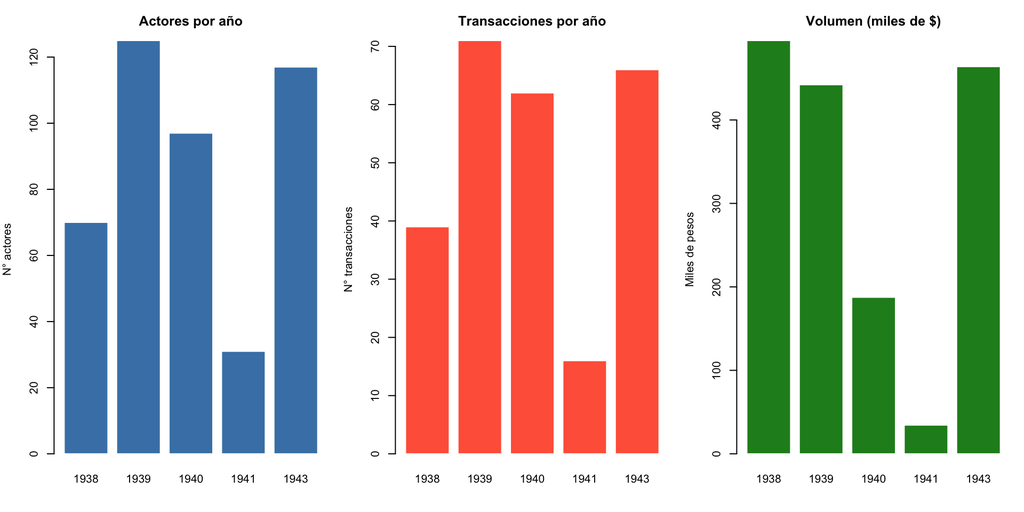

```r
par(mfrow = c(1, 3), mar = c(4, 4, 3, 1))

barplot(stats_año$Actores,
        names.arg = stats_año$Año,
        col = "steelblue", border = "white",
        main = "Actores por año",
        ylab = "N° actores")

barplot(stats_año$Transac,
        names.arg = stats_año$Año,
        col = "tomato", border = "white",
        main = "Transacciones por año",
        ylab = "N° transacciones")

barplot(stats_año$Vol_pesos / 1000,
        names.arg = stats_año$Año,
        col = "forestgreen", border = "white",
        main = "Volumen (miles de $)",
        ylab = "Miles de pesos")
```

```r
par(mfrow = c(1, 1))
```

## 8.3 Exploración libre: elige un año

**Pista:** Cambia el número en `año_elegido <- 1940` por cualquier otro año del expediente (1938, 1939, 1941 o 1943) para ver los actores más activos en ese momento específico.

```r
# ── Cambia este valor para explorar otro año ──
año_elegido <- 1940

datos_año <- datos %>% filter(fecha == año_elegido)

vend <- datos_año %>% count(vendedor,  name = "v") %>% rename(actor = vendedor)
comp <- datos_año %>% count(comprador, name = "c") %>% rename(actor = comprador)

top_año <- full_join(vend, comp, by = "actor") %>%
  replace(is.na(.), 0) %>%
  mutate(total = v + c) %>%
  arrange(desc(total))

cat("Top 10 actores en", año_elegido, ":\n")
```

```
## Top 10 actores en 1940 :
```

```r
head(top_año, 10)
```

|  | actor | v | c | total |
| --- | --- | --- | --- | --- |
| 1 | Sebastian Caicedo | 4 | 6 | 10 |
| 2 | Susana Caicedo | 6 | 0 | 6 |
| 3 | Rosa Lowid de Arboleda | 4 | 0 | 4 |
| 4 | Guillermo Gonzalez | 3 | 0 | 3 |
| 5 | Nila Osorio de Garces | 2 | 1 | 3 |
| 6 | Ana Borrero | 2 | 0 | 2 |
| 7 | Elbia Caicedo de Montilla | 1 | 1 | 2 |
| 8 | Juan Castillo | 2 | 0 | 2 |
| 9 | Juana Mosquera | 1 | 1 | 2 |
| 10 | Leon E Aerich | 2 | 0 | 2 |

**Ejercicio 7 — El factor tiempo**

1. ¿En qué año hay más transacciones? ¿Y mayor volumen de dinero? ¿Coinciden los dos picos? Si no coinciden, ¿qué puede explicar la diferencia?
2. La Segunda Guerra Mundial cortó las importaciones europeas y generó inflación en América Latina a partir de 1940. ¿Ves algún cambio notable en el mercado inmobiliario entre 1938–1939 y 1940–1941? ¿Sube o baja la actividad? Formula una hipótesis.
3. Explora **al menos dos años distintos** con el bloque de exploración libre. ¿Hay actores que solo aparecen en un año? ¿Hay actores que aparecen en todos los años? ¿Qué dice eso sobre quiénes son los actores estructurales del mercado y quiénes son oportunistas o transitorios?

*Escribe tus respuestas aquí:*

> 1. —
> 2. —
> 3. —

# Veredicto

Ya tienes todas las pistas. Es hora de resolver el caso.

**Veredicto final**

Escribe un párrafo de **6 a 10 oraciones** respondiendo:

*¿Quién controlaba el mercado inmobiliario de Cali entre 1938 y 1943? ¿Cómo se relacionaban entre sí los actores más poderosos? ¿Qué tipo de poder ejercían — volumen de transacciones, posición de puente, pertenencia a una comunidad? ¿Qué dice esto sobre el proceso de urbanización de Cali en esa época?*

Usa evidencia concreta de los análisis anteriores: nombres de actores, cifras, estructuras de red. No generalices sin datos.

*Escribe tu veredicto aquí:*

> —

# Para tu proyecto

**Grupo A — Red Social**

Los métodos de hoy aplican directamente a tu red de relaciones sociales entre familias de élite. Identifica quiénes tienen la mayor **intermediación** en tu red: ¿son los mismos que tienen mayor grado? ¿Las comunidades detectadas coinciden con clanes familiares reales o con asociaciones conocidas (Club Colombia, Club Campestre, juntas directivas)? La pregunta de fondo es la misma que para los Medici: ¿quién conecta círculos que de otra forma no se conectarían?

**Grupo B — Red Inmobiliaria**

Este es tu conjunto de datos. Profundiza más allá del taller: ¿Puedes rastrear una misma propiedad en varias transacciones sucesivas? ¿Hay actores que compran barato y revenden caro? ¿Los tipos de negocio (compraventa, hipoteca, cancelación) se concentran en actores distintos? ¿Qué barrios concentran más actividad, y cómo cambia eso con el tiempo?

**Grupo C — Red Espacial**

Tu red conecta lugares, no personas — pero los métodos son exactamente los mismos. ¿Qué lugares tienen mayor grado (más conexiones con otros lugares)? ¿Qué calles o nodos son puentes entre zonas de la ciudad (alta intermediación)? ¿Las comunidades espaciales detectadas coinciden con barrios históricos o con zonas funcionales (comercial, residencial, industrial)? Además, cruza con los grupos A y B: ¿los actores más poderosos de la red inmobiliaria concentran propiedades en los mismos barrios?

*Taller preparado para el curso Introducción a la Complejidad 2026-I — Universidad del Valle.*